# Machine Learning: Course Project

## [Human Activity Recognition](http://groupware.les.inf.puc-rio.br/har#weight_lifting_exercises)

Using devices such as Jawbone Up, Nike FuelBand, and Fitbit it is now possible to collect a large amount of data about personal activity relatively inexpensively. These type of devices are part of the quantified self movement – a group of enthusiasts who take measurements about themselves regularly to improve their health, to find patterns in their behavior, or because they are tech geeks. One thing that people regularly do is quantify how much of a particular activity they do, but they rarely quantify how well they do it.

## [Weight Lifting Exercise Data Set](http://groupware.les.inf.puc-rio.br/har#weight_lifting_exercises)

The Weight Lifting Exercises dataset investigates “how well” an activity was performed by the wearer. Six young health participants were asked to perform one set of 10 repetitions of the Unilateral Dumbbell Biceps Curl in five different fashions: exactly according to the specification (Class A), throwing the elbows to the front (Class B), lifting the dumbbell only halfway (Class C), lowering the dumbbell only halfway (Class D) and throwing the hips to the front (Class E).Class A corresponds to the specified execution of the exercise, while the other 4 classes correspond to common mistakes.

## Project Goal

The project goal is to use data from accelerometers on the belt, forearm, arm, and dumbell of 6 participants to predict the manner in which they did the exercise. The manner in which they did the exercise is categorized into Classes A to E.

### [Training Data](https://d396qusza40orc.cloudfront.net/predmachlearn/pml-training.csv)

### [Testing Data](https://d396qusza40orc.cloudfront.net/predmachlearn/pml-testing.csv)

## Load the required packages and the data

```r
library(randomForest)
library(caret)
origdf <- read.csv("pml-training.csv",na.strings=c("NA","NaN", " ",""))
```

## Preprocess the data

### Remove predictors with near zero variance

On inspection of the data, it can be seen that several predictors have near zero variance. As they do not contribute usefully to the prediction, they can be removed. If a column has NA and NaN values for more than 40% of the observations, they are removed.

```r
#Initialize a dataframe.
df <- data.frame(matrix(NA, nrow=1, ncol=1))
y <- round(19622 * 0.4)
#Initialize a vactor to stor column id
colid <- numeric()
for( i in 1:160){
      x <- sum(is.na(origdf[,i]))
      #If count of NA is less than threshold add column to new dataframe.
      if ( x < y){
            df <- cbind(df,origdf[,i])
            colid <- c(colid,i)
      }
}
df <- subset(df, select = -c(1) )
#Add column names
origcolumnnames <- colnames(origdf)
colidlen <- length(colid)
dfcolnames <- character()
for( i in 1:colidlen){
      temp <- colid[i]
      dfcolnames <- c(dfcolnames,origcolumnnames[temp])
}
colnames(df) <- dfcolnames
```

### Remove columns which do not contribute to prediction.

Columns 1 to 6 contain data which do not influence the outcome, hence can be removed.

```r
df <- subset(df, select = -c(1,2,3,4,5,6) )
```

## Machine Learning Algorithm - Random Forests Classification

The Random Forests algorithm has been chosen due to the following reasons. 1. There are large number of predictors. 2. Some of the predictors are highly correlated while some are not. 3. Random forests algorithm takes care of cross validation internally. 4. Random Forests list the variable importance.

When the training set for the current tree is drawn by sampling with replacement, about one-third of the cases are left out of the sample. This oob (out-of-bag) data is used to get a running unbiased estimate of the classification error as trees are added to the forest. It is also used to get estimates of variable importance. (https://www.stat.berkeley.edu/~breiman/RandomForests/cc_home.htm#workings)

```r
df.rf <-randomForest(classe~.,data=df, ntree=50)
df.rf
```

```
##
## Call:
##  randomForest(formula = classe ~ ., data = df, ntree = 50)
##                Type of random forest: classification
##                      Number of trees: 50
## No. of variables tried at each split: 7
##
##         OOB estimate of  error rate: 0.25%
## Confusion matrix:
##      A    B    C    D    E class.error
## A 5579    0    0    0    1   0.0001792
## B    7 3782    6    2    0   0.0039505
## C    0   11 3411    0    0   0.0032145
## D    0    0   17 3197    2   0.0059080
## E    0    0    0    3 3604   0.0008317
```

The importance of the predictors:

```r
importance(df.rf)
```

```
##                      MeanDecreaseGini
## num_window                    1294.87
## roll_belt                     1102.33
## pitch_belt                     675.53
## yaw_belt                       909.52
## total_accel_belt               252.67
## gyros_belt_x                    66.68
## gyros_belt_y                   123.71
## gyros_belt_z                   245.03
## accel_belt_x                   112.29
## accel_belt_y                   173.44
## accel_belt_z                   300.27
## magnet_belt_x                  250.52
## magnet_belt_y                  419.19
## magnet_belt_z                  317.99
## roll_arm                       316.32
## pitch_arm                      152.53
## yaw_arm                        179.53
## total_accel_arm                 83.18
## gyros_arm_x                    107.66
## gyros_arm_y                    121.61
## gyros_arm_z                     48.37
## accel_arm_x                    235.18
## accel_arm_y                    131.71
## accel_arm_z                    118.34
## magnet_arm_x                   260.51
## magnet_arm_y                   215.33
## magnet_arm_z                   143.54
## roll_dumbbell                  368.37
## pitch_dumbbell                 168.09
## yaw_dumbbell                   224.03
## total_accel_dumbbell           260.77
## gyros_dumbbell_x               115.68
## gyros_dumbbell_y               198.36
## gyros_dumbbell_z                72.66
## accel_dumbbell_x               248.47
## accel_dumbbell_y               384.70
## accel_dumbbell_z               279.41
## magnet_dumbbell_x              442.34
## magnet_dumbbell_y              654.44
## magnet_dumbbell_z              690.38
## roll_forearm                   575.79
## pitch_forearm                  682.46
## yaw_forearm                    142.17
## total_accel_forearm            110.58
## gyros_forearm_x                 57.20
## gyros_forearm_y                 98.69
## gyros_forearm_z                 63.64
## accel_forearm_x                345.90
## accel_forearm_y                105.44
## accel_forearm_z                235.46
## magnet_forearm_x               170.44
## magnet_forearm_y               197.22
## magnet_forearm_z               264.47
```

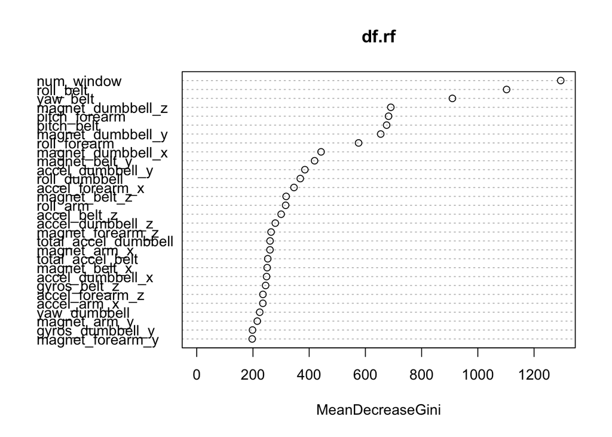

```r
varImpPlot(df.rf,scale=FALSE)
```

The plot shows the mean decrease gini of the various predictors.

## Testing the Model

### Load and preprocess Test data

```r
origtestdf <- read.csv("pml-testing.csv",na.strings=c("NA","NaN", " ",""))
testdf <- subset(origtestdf, select = colid)
testdf <- subset(testdf, select = -c(1,2,3,4,5,6) )
```

### Predict classification for Test Data

```r
testdf.rf.pr = predict(df.rf, newdata=testdf)
```

## Submitting Test Results

The results were submitted at (https://class.coursera.org/predmachlearn-005/assignment). It could be seen that the classification was 100% correct.